# Brief demo of tidy evaluation

Brittany Barker & John Smith

3/18/2022

Tidy evaluation is a framework for controlling how expressions and variables in your code are evaluated by tidyverse functions, as described in this [R-bloggers blog](https://www.r-bloggers.com/2019/12/practical-tidy-evaluation/#:~:text=Tidy%20evaluation%20is%20a%20framework,more%20efficient%20and%20elegant%20code).

The Tidy evaluation [chapter](https://tidyeval.tidyverse.org/index.html) of the `tidyverse` guide book recommends reading:  
- The new [Programming with dplyr](https://dplyr.tidyverse.org/articles/programming.html) vignette.  
- The [Using ggplot2 in packages](https://ggplot2.tidyverse.org/articles/ggplot2-in-packages.html) vignette.

As described in the dplyr vignette, most dplyr verbs use **tidy evaluation** in some way. The two basic forms of tidy evaluation in dplyr are those that use:  
- **data masking** so that you can use data variables as they were variables in the environment (i.e. you write `my_variable` not `df$myvariable`). These include `arrange()`, `count()`, `filter()`, `group_by()`, `mutate()`, and `summarise()`.  
- **tidy selection** so you can easily choose variables based on their position, name, or type (e.g. `starts_with("x")` or `is.numeric`. These include `across()`, `relocate()`, `rename()`, `select()`, and `pull()`.

In this demo, we’ll cover some examples of both forms of tidy evaluation using the `penguins` dataset.

## Data-variables vs. env-variables

**Data masking** blurs the line between two different meanings of the word “variable.”  
- **env-variables** are “programming” variables that live in the environment (e.g., the `penguins` data frame).  
- **data-variables** are “statistical” variables that live in a data frame (e.g., the 8 variables in the `penguins` data frame).

```r
str(penguins)
```

```
## tibble [344 x 8] (S3: tbl_df/tbl/data.frame)
##  $ species          : Factor w/ 3 levels "Adelie","Chinstrap",..: 1 1 1 1 1 1 1 1 1 1 ...
##  $ island           : Factor w/ 3 levels "Biscoe","Dream",..: 3 3 3 3 3 3 3 3 3 3 ...
##  $ bill_length_mm   : num [1:344] 39.1 39.5 40.3 NA 36.7 39.3 38.9 39.2 34.1 42 ...
##  $ bill_depth_mm    : num [1:344] 18.7 17.4 18 NA 19.3 20.6 17.8 19.6 18.1 20.2 ...
##  $ flipper_length_mm: int [1:344] 181 186 195 NA 193 190 181 195 193 190 ...
##  $ body_mass_g      : int [1:344] 3750 3800 3250 NA 3450 3650 3625 4675 3475 4250 ...
##  $ sex              : Factor w/ 2 levels "female","male": 2 1 1 NA 1 2 1 2 NA NA ...
##  $ year             : int [1:344] 2007 2007 2007 2007 2007 2007 2007 2007 2007 2007 ...
```

```r
head(penguins)
```

```
## # A tibble: 6 x 8
##   species island bill_length_mm bill_depth_mm flipper_length_~ body_mass_g sex
##   <fct>   <fct>           <dbl>         <dbl>            <int>       <int> <fct>
## 1 Adelie  Torge~           39.1          18.7              181        3750 male
## 2 Adelie  Torge~           39.5          17.4              186        3800 fema~
## 3 Adelie  Torge~           40.3          18                195        3250 fema~
## 4 Adelie  Torge~           NA            NA                 NA          NA <NA>
## 5 Adelie  Torge~           36.7          19.3              193        3450 fema~
## 6 Adelie  Torge~           39.3          20.6              190        3650 male
## # ... with 1 more variable: year <int>
```

When you want to get the data-variable from an environmental variable without typing the variable’s name, you need to **embrace** the argument surrounding it in double braces. The following function uses embracing to create a wrapper around `summarise` (and other functions). Note that `summarise()` and `summarize()` can be used interchangeably.

```r
var_min_max <- function(df, var){
  df %>%
    summarize(min = min({{ var }}, na.rm = TRUE), max = max({{ var }}, na.rm = TRUE))
}

penguins %>%
  group_by(species) %>%
  var_min_max(bill_length_mm)
```

```
## # A tibble: 3 x 3
##   species     min   max
##   <fct>     <dbl> <dbl>
## 1 Adelie     32.1  46
## 2 Chinstrap  40.9  58
## 3 Gentoo     40.9  59.6
```

When you have an env-variable that is a character vector, you need to index into the `.data` pronoun with `[[`, like `summarise(penguins, mean(.data[[var]]))`.

```r
var_list <- c("bill_length_mm", "bill_depth_mm", "flipper_length_mm", "body_mass_g")
for (var in var_list){
  penguins %>%
    summarise(mean = mean(.data[[var]], na.rm = TRUE)) %>% print()
}
```

```
## # A tibble: 1 x 1
##    mean
##   <dbl>
## 1  43.9
## # A tibble: 1 x 1
##    mean
##   <dbl>
## 1  17.2
## # A tibble: 1 x 1
##    mean
##   <dbl>
## 1  201.
## # A tibble: 1 x 1
##    mean
##   <dbl>
## 1 4202.
```

## Tidy selection

Tidy selection is a complementary tool to data masking that makes it easy to work with the columns of a data frame. Underneath all functions that use tidy selection is the `tidyselect` package. It provides a miniature domain specific language that makes it easy to select columns by name, position, or type. Here are some examples.

Selects the first column (`last_col()` selects the last column).

```r
head(select(penguins, 1))
```

```
## # A tibble: 6 x 1
##   species
##   <fct>
## 1 Adelie
## 2 Adelie
## 3 Adelie
## 4 Adelie
## 5 Adelie
## 6 Adelie
```

Select columns by name.

```r
head(select(penguins, c(species, island, body_mass_g)))
```

```
## # A tibble: 6 x 3
##   species island    body_mass_g
##   <fct>   <fct>           <int>
## 1 Adelie  Torgersen        3750
## 2 Adelie  Torgersen        3800
## 3 Adelie  Torgersen        3250
## 4 Adelie  Torgersen          NA
## 5 Adelie  Torgersen        3450
## 6 Adelie  Torgersen        3650
```

Selects all columns whose name starts with “bill.”

```r
head(select(penguins, starts_with("bill")))
```

```
## # A tibble: 6 x 2
##   bill_length_mm bill_depth_mm
##            <dbl>         <dbl>
## 1           39.1          18.7
## 2           39.5          17.4
## 3           40.3          18
## 4           NA            NA
## 5           36.7          19.3
## 6           39.3          20.6
```

Select all columns whose name ends with “mm.”

```r
head(select(penguins, ends_with("mm")))
```

```
## # A tibble: 6 x 3
##   bill_length_mm bill_depth_mm flipper_length_mm
##            <dbl>         <dbl>             <int>
## 1           39.1          18.7               181
## 2           39.5          17.4               186
## 3           40.3          18                 195
## 4           NA            NA                  NA
## 5           36.7          19.3               193
## 6           39.3          20.6               190
```

Select all numeric columns.

```r
head(select(penguins, where(is.numeric)))
```

```
## # A tibble: 6 x 5
##   bill_length_mm bill_depth_mm flipper_length_mm body_mass_g  year
##            <dbl>         <dbl>             <int>       <int> <int>
## 1           39.1          18.7               181        3750  2007
## 2           39.5          17.4               186        3800  2007
## 3           40.3          18                 195        3250  2007
## 4           NA            NA                  NA          NA  2007
## 5           36.7          19.3               193        3450  2007
## 6           39.3          20.6               190        3650  2007
```

Use the negation of select to remove columns.

```r
head(select(penguins, -c(year, sex)))
```

```
## # A tibble: 6 x 6
##   species island    bill_length_mm bill_depth_mm flipper_length_mm body_mass_g
##   <fct>   <fct>              <dbl>         <dbl>             <int>       <int>
## 1 Adelie  Torgersen           39.1          18.7               181        3750
## 2 Adelie  Torgersen           39.5          17.4               186        3800
## 3 Adelie  Torgersen           40.3          18                 195        3250
## 4 Adelie  Torgersen           NA            NA                  NA          NA
## 5 Adelie  Torgersen           36.7          19.3               193        3450
## 6 Adelie  Torgersen           39.3          20.6               190        3650
```

## Some more summarize examples

Usually with summarize, you want to group data first. First let’s do some analyses in which we’ll group the `penguins` data by species. There are three species (Adelie, Chinstrap, and Gentoo).

```r
penguins %>%
  group_by(species) %>%
  distinct(species)
```

```
## # A tibble: 3 x 1
## # Groups:   species [3]
##   species
##   <fct>
## 1 Adelie
## 2 Gentoo
## 3 Chinstrap
```

Group data by island and calculate the number of species on each island.

```r
penguins %>%
  group_by(island) %>%
  distinct(species, .keep_all = TRUE) %>%
  summarize(n())
```

```
## # A tibble: 3 x 2
##   island    `n()`
##   <fct>     <int>
## 1 Biscoe        2
## 2 Dream         2
## 3 Torgersen     1
```

Summarize bill and flipper length measurements (columns contain “mm” string) using the `mean` function. This involves grouping data by species, rounding results, renaming columns, and creating a table of results using the `gt` package. Notice that the `across` function is used to round all numeric columns.

```r
mean_bill_flip <- penguins %>%
  group_by(species) %>%
  summarize(across(ends_with("mm"), mean, na.rm = TRUE)) %>%
  mutate(across(where(is.numeric), round, 2)) %>%
  setNames(c("Species", "Bill length (mm)", "Bill depth (mm)", "Flipper length (mm)"))

gt(mean_bill_flip) %>%
  cols_align(align = "left") %>%
  tab_header(title = md("**Trait measurements for three penguin species**"),
             subtitle = "Averages for bill and flipper lengths")
```

**Trait measurements for three penguin species**

Averages for bill and flipper lengths

| Species | Bill length (mm) | Bill depth (mm) | Flipper length (mm) |
| --- | --- | --- | --- |
| Adelie | 38.79 | 18.35 | 189.95 |
| Chinstrap | 48.83 | 18.42 | 195.82 |
| Gentoo | 47.50 | 14.98 | 217.19 |

The `tidyselect` grammar can also be used in some places in the construction of a `gt` table. For example, we can just show 1 decimal place for the numeric variables. Other handy format functions that are `tidyselect`-aware are `fmt_currency`, `fmt_date`, `fmt_time`, `fmt_datetime`, `fmt_percent`, and `fmt_markdown`.

```r
gt(mean_bill_flip) %>%
  cols_align(align = "left") %>%
  fmt_number(where(is.numeric), decimals = 1) %>%
  tab_header(title = md("**Trait measurements for three penguin species**"),
             subtitle = "Averages for bill and flipper lengths")
```

**Trait measurements for three penguin species**

Averages for bill and flipper lengths

| Species | Bill length (mm) | Bill depth (mm) | Flipper length (mm) |
| --- | --- | --- | --- |
| Adelie | 38.8 | 18.4 | 189.9 |
| Chinstrap | 48.8 | 18.4 | 195.8 |
| Gentoo | 47.5 | 15.0 | 217.2 |

Are there differences in flipper length between species? To answer this question, we summarize flipper length using the `quantile` function, which by default returns data divided into 0% (min), 25% (lower), 50% (median), 75% (upper), and 100% (max) subsets. This involves grouping flipper length data by species, removing missing data, and calculating quantiles.

```r
quants <- penguins %>%
  group_by(species) %>%
  na.omit() %>%
  summarize(flipper = list(quantile(flipper_length_mm)))
```

Show the characteristics of the output:

```r
str(quants)
```

```
## tibble [3 x 2] (S3: tbl_df/tbl/data.frame)
##  $ species: Factor w/ 3 levels "Adelie","Chinstrap",..: 1 2 3
##  $ flipper:List of 3
##   ..$ : Named num [1:5] 172 186 190 195 210
##   .. ..- attr(*, "names")= chr [1:5] "0%" "25%" "50%" "75%" ...
##   ..$ : Named num [1:5] 178 191 196 201 212
##   .. ..- attr(*, "names")= chr [1:5] "0%" "25%" "50%" "75%" ...
##   ..$ : Named num [1:5] 203 212 216 222 231
##   .. ..- attr(*, "names")= chr [1:5] "0%" "25%" "50%" "75%" ...
```

```r
quants
```

```
## # A tibble: 3 x 2
##   species   flipper
##   <fct>     <list>
## 1 Adelie    <dbl [5]>
## 2 Chinstrap <dbl [5]>
## 3 Gentoo    <dbl [5]>
```

```r
quants_flipper <- quants %>%
  unnest_wider(flipper) # have a look at unnest_longer(flipper), too.

quants_flipper
```

```
## # A tibble: 3 x 6
##   species    `0%` `25%` `50%` `75%` `100%`
##   <fct>     <dbl> <dbl> <dbl> <dbl>  <dbl>
## 1 Adelie      172   186   190  195     210
## 2 Chinstrap   178   191   196  201     212
## 3 Gentoo      203   212   216  222.    231
```

Next, the results are plotted using `geom_boxplot` in `ggplot2`. The `ggplot2` pacakge has support for tidy evaluation.

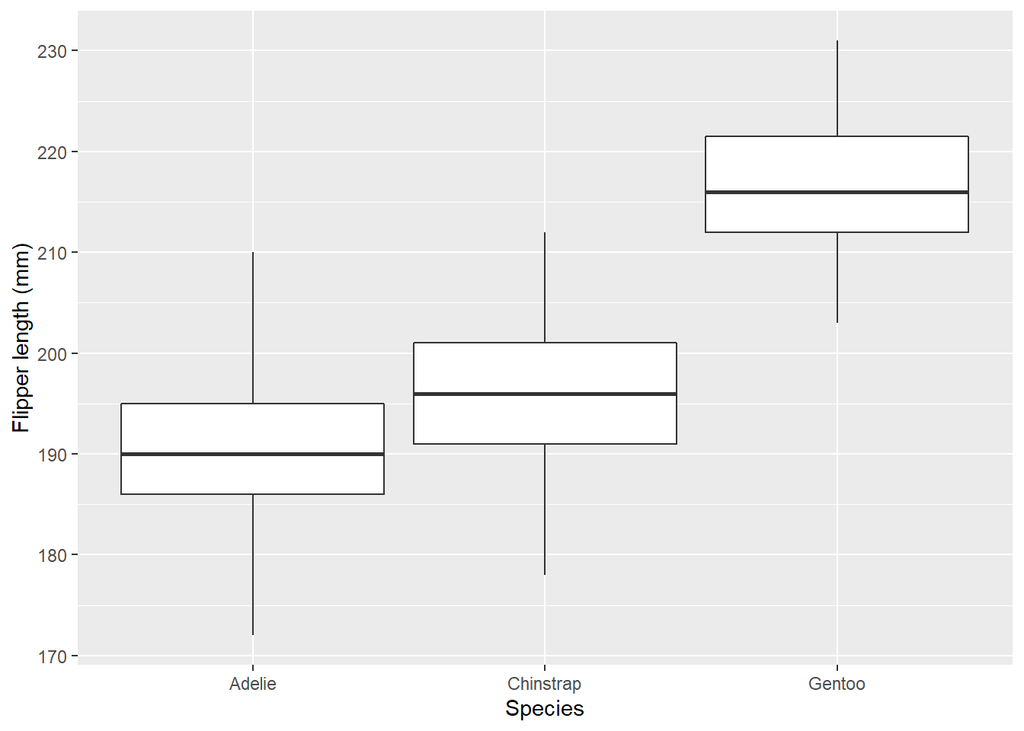

```r
ggplot(quants_flipper, aes(x = species)) +
  geom_boxplot(
    aes(ymin = `0%`, lower = `25%`, middle = `50%`, upper = `75%`, ymax = `100%`),
    stat = "identity"
    ) +
  xlab("Species") +
  ylab("Flipper length (mm)")
```

Use `where(is.numeric)` and its negation to format the table:

```r
quants_flipper %>%
  gt() %>%
  fmt_number(where(is.numeric), decimals = 1) %>%
  cols_align(!where(is.numeric), align = "right")
```

| species | 0% | 25% | 50% | 75% | 100% |
| --- | --- | --- | --- | --- | --- |
| Adelie | 172.0 | 186.0 | 190.0 | 195.0 | 210.0 |
| Chinstrap | 178.0 | 191.0 | 196.0 | 201.0 | 212.0 |
| Gentoo | 203.0 | 212.0 | 216.0 | 221.5 | 231.0 |

## Conditional summarize functions

Here are some examples of how to conditionally summarize data using `summarize_if`, `summarize_at`, and `summarize_all`.

Here `summarize_if` is used to calculate mean of numeric columns. We exclude year using `select`.

```r
penguins %>%
  select(-year) %>%
  group_by(species) %>%
  summarise_if(is.numeric, mean, na.rm = TRUE)
```

```
## # A tibble: 3 x 5
##   species   bill_length_mm bill_depth_mm flipper_length_mm body_mass_g
##   <fct>              <dbl>         <dbl>             <dbl>       <dbl>
## 1 Adelie              38.8          18.3              190.       3701.
## 2 Chinstrap           48.8          18.4              196.       3733.
## 3 Gentoo              47.5          15.0              217.       5076.
```

Here `summarize_at` is used to calculate mean of columns only containing the string “mm” (corresponding to bill and flipper lengths).

```r
penguins %>%
  group_by(species) %>%
  summarise_at(vars(contains("mm")), mean, na.rm = TRUE)
```

```
## # A tibble: 3 x 4
##   species   bill_length_mm bill_depth_mm flipper_length_mm
##   <fct>              <dbl>         <dbl>             <dbl>
## 1 Adelie              38.8          18.3              190.
## 2 Chinstrap           48.8          18.4              196.
## 3 Gentoo              47.5          15.0              217.
```

Here `summarize_all` is used to summarize data in all columns. However, notice how we get a warning message because we’re asking the function to summarize `sex` and `island`, which are factors (the other columns are integer or numeric variables). Also, it doesn’t really make sense to calculate the mean year.

```r
penguins %>%
  group_by(species) %>%
  summarise_all(~mean(., na.rm = TRUE))
```

```
## Warning in mean.default(., na.rm = TRUE): argument is not numeric or logical:
## returning NA

## Warning in mean.default(., na.rm = TRUE): argument is not numeric or logical:
## returning NA

## Warning in mean.default(., na.rm = TRUE): argument is not numeric or logical:
## returning NA

## Warning in mean.default(., na.rm = TRUE): argument is not numeric or logical:
## returning NA

## Warning in mean.default(., na.rm = TRUE): argument is not numeric or logical:
## returning NA

## Warning in mean.default(., na.rm = TRUE): argument is not numeric or logical:
## returning NA
```

```
## # A tibble: 3 x 8
##   species island bill_length_mm bill_depth_mm flipper_length_~ body_mass_g   sex
##   <fct>    <dbl>          <dbl>         <dbl>            <dbl>       <dbl> <dbl>
## 1 Adelie      NA           38.8          18.3             190.       3701.    NA
## 2 Chinst~     NA           48.8          18.4             196.       3733.    NA
## 3 Gentoo      NA           47.5          15.0             217.       5076.    NA
## # ... with 1 more variable: year <dbl>
```

Thus, we’d either not want to use `summarize_all` in this context, or we could remove the problematic columns before we apply the function. This can be accomplished using the negation operator in the `select` function.

```r
penguins %>%
  group_by(species) %>%
  select(-year, -island, -sex) %>%
  summarise_all(~mean(., na.rm = TRUE))
```

```
## # A tibble: 3 x 5
##   species   bill_length_mm bill_depth_mm flipper_length_mm body_mass_g
##   <fct>              <dbl>         <dbl>             <dbl>       <dbl>
## 1 Adelie              38.8          18.3              190.       3701.
## 2 Chinstrap           48.8          18.4              196.       3733.
## 3 Gentoo              47.5          15.0              217.       5076.
```